# How To Video Ch02 Income

Bruce Hartman

University of St. Francis

2025-08-07

Abstract

This notebook is for a How-to Video.

# Introduction

We will study the Income data from Chapter 2 of (ISLR, 2013).

# Packages

Packages are ways R uses to let users write their own commands. They allow R to be open source and gain user involvement with the latest features.

The `devtools` package will be installed, if you have not already done so, and loaded. Then we install and load package `mbadtools` from GitHub. This package is used in USF’s MBAD courses and is not on CRAN. The `mbad_standard_packages` object contains a list of required packages for this course that you will need to install first.

```r
# allow package installation from github
if(!("devtools" %in% installed.packages())) install.packages("devtools")
library(devtools) # Make sure that the devtools library is loaded
# install mbadtools from github
if(!("mbadtools" %in% installed.packages())) devtools::install_github("bhartman2/mbadtools")
# load github packages
library(mbadtools)
# list of packages to install
data("mbad_standard_packages")
mbad_standard_packages
```

```
 [1] "tidyverse"    "ggfortify"    "GGally"       "skimr"        "broom"        "gt"           "patchwork"
 [8] "car"          "yardstick"    "ggResidpanel"
```

```r
# load packages to the notebook
lib_packages(mbad_standard_packages, quiet=TRUE)
```

```
Loading MBAD packages:
 tidyverse ggfortify GGally skimr broom gt patchwork car yardstick ggResidpanel
```

# Data

Here we get the data using Import Dataset from a csv file Import2.csv.

```r
library(readr)
Income <- read_csv("Income2.csv")
```

Display the data to see I got it.

```r
Income
```

| ...1 | Education | Seniority | Income |
| --- | --- | --- | --- |
| 1 | 21.58621 | 113.10345 | 99.91717 |
| 2 | 18.27586 | 119.31034 | 92.57913 |
| 3 | 12.06897 | 100.68966 | 34.67873 |
| 4 | 17.03448 | 187.58621 | 78.70281 |
| 5 | 19.93103 | 20.00000 | 68.00992 |
| 6 | 18.27586 | 26.20690 | 71.50449 |
| 7 | 19.93103 | 150.34483 | 87.97047 |
| 8 | 21.17241 | 82.06897 | 79.81103 |
| 9 | 20.34483 | 88.27586 | 90.00633 |
| 10 | 10.00000 | 113.10345 | 45.65553 |

[output cut: 20 more lines]

# Data Description

Describe the data using simple display, or `skim`.

```r
Income %>% skim()
```

```
── Data Summary ────────────────────────
                           Values
Name                       Piped data
Number of rows             30
Number of columns          4
_______________________
Column type frequency:
  numeric                  4
________________________
Group variables            None
```

|  | skim_variable | n_missing | complete_rate | mean | sd | p0 | p25 | p50 | p75 | p100 | hist |
| --- | --- | --- | --- | --- | --- | --- | --- | --- | --- | --- | --- |
| 1 | ...1 | 0 | 1 | 15.50000 | 8.803408 | 1.00000 | 8.25000 | 15.50000 | 22.75000 | 30.00000 | ▇▇▇▇▇ |
| 2 | Education | 0 | 1 | 16.38621 | 3.810622 | 10.00000 | 12.48276 | 17.03448 | 19.93103 | 21.58621 | ▇▂▂▆▇ |
| 3 | Seniority | 0 | 1 | 93.86207 | 55.715623 | 20.00000 | 44.82759 | 94.48276 | 133.27586 | 187.58621 | ▇▂▇▂▃ |
| 4 | Income | 0 | 1 | 62.74473 | 27.013285 | 17.61359 | 36.39204 | 70.80479 | 85.93061 | 99.91717 | ▆▂▂▇▇ |

# Research Problem

We will try to find out if there is a relationship between `Income` and `Education` level and `Seniority`.

# Data Wrangling

Make changes to the data for analysis.

```r
Income = Income %>% rename(ID = `...1`)
Income %>% glimpse
```

```
Rows: 30
Columns: 4
$ ID        <dbl> 1, 2, 3, 4, 5, 6, 7, 8, 9, 10, 11, 12, 13, 14, 15, 16, 17, 18, 19, 20, 21, 22, 23, 24, 25…
$ Education <dbl> 21.58621, 18.27586, 12.06897, 17.03448, 19.93103, 18.27586, 19.93103, 21.17241, 20.34483,…
$ Seniority <dbl> 113.10345, 119.31034, 100.68966, 187.58621, 20.00000, 26.20690, 150.34483, 82.06897, 88.2…
$ Income    <dbl> 99.91717, 92.57913, 34.67873, 78.70281, 68.00992, 71.50449, 87.97047, 79.81103, 90.00633,…
```

# Data Visualization

Graphic displays of data such as pairs plot.

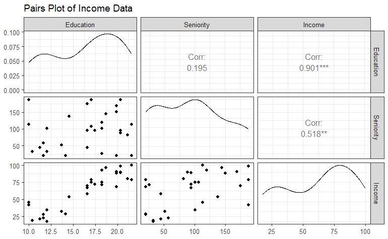

```r
Income %>% select(-ID) %>%
  ggpairs(progress=F) +
  theme_bw() +
  labs(title="Pairs Plot of Income Data")
```

# Linear Regression

We run a regression of `Income` on `Education` and `Seniority`.

```r
model1 <- lm(Income ~ Education + Seniority, data=Income)
```

See the results:

```r
summary(model1)
```

```
Call:
lm(formula = Income ~ Education + Seniority, data = Income)

Residuals:
   Min     1Q Median     3Q    Max
-9.113 -5.718 -1.095  3.134 17.235

Coefficients:
             Estimate Std. Error t value Pr(>|t|)
(Intercept) -50.08564    5.99878  -8.349 5.85e-09 ***
Education     5.89556    0.35703  16.513 1.23e-15 ***
Seniority     0.17286    0.02442   7.079 1.30e-07 ***
---
Signif. codes:  0 ‘***’ 0.001 ‘**’ 0.01 ‘*’ 0.05 ‘.’ 0.1 ‘ ’ 1

Residual standard error: 7.187 on 27 degrees of freedom
Multiple R-squared:  0.9341,    Adjusted R-squared:  0.9292
F-statistic: 191.4 on 2 and 27 DF,  p-value: < 2.2e-16
```

Use modern way.

```r
model1 %>% glance
```

| r.squared | adj.r.squared | sigma | statistic | p.value | df | logLik | AIC | BIC | deviance | df.residual | nobs |
| --- | --- | --- | --- | --- | --- | --- | --- | --- | --- | --- | --- |
| 0.9341035 | 0.9292223 | 7.186634 | 191.3669 | 1.134064e-16 | 2 | -100.1544 | 208.3089 | 213.9137 | 1394.488 | 27 | 30 |

```r
model1 %>% tidy
```

| term | estimate | std.error | statistic | p.value |
| --- | --- | --- | --- | --- |
| (Intercept) | -50.0856388 | 5.99877911 | -8.349305 | 5.850415e-09 |
| Education | 5.8955560 | 0.35703114 | 16.512722 | 1.230258e-15 |
| Seniority | 0.1728555 | 0.02441884 | 7.078775 | 1.304884e-07 |

# Conclusion

My conclusions are that `Income` does depend on `Education` and `Seniority` taken together. The linear regression has significant coefficients.

# References

1. Hartman, B. (2024) Basic Notebook Template. (https://github.com/bhartman2/mbadtools/blob/main/notebook/Basic%20Notebook%20Template.Rmd)
2. ISLR (2013) An Introduction to Statistical Learning with Applications in R. (https://www.statlearning.com/)